# combined_pca

## PCA

### WT-NC vs WT-HFD

**Scores Plot of PCA**

This figure shows a Principal Component Analysis (PCA) scores plot illustrating the variations in metabolite profiles of mice under WT-NC and WT-HFD groups. Each point represents a sample, with clusters indicating separation or overlap between the two groups based on their metabolic profiles.

The first and second principal components explain approximately 30% and 12% of the total variation in metabolites for mice under WT-NC and WT-HFD groups.

Each point represents a sample, with colors indicating different groups. The PERMANOVA test shows no significant difference in centroids between WT-NC and WT-HFD groups (PERMANOVA F-value: 0.85366; R-squared: 0.078652; p-value (based on 999 permutations): 0.457).

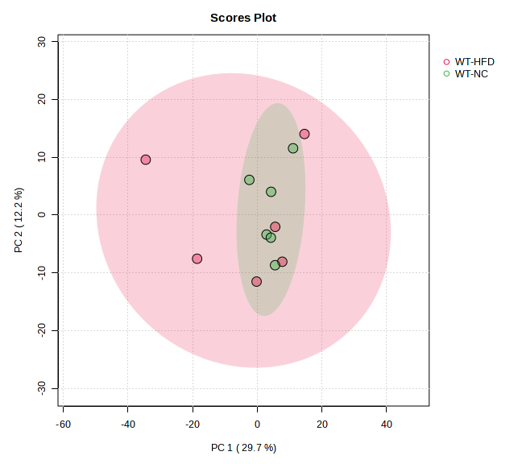

**Figure 5. PCA Scores Plot - Metabolite Profile Variations in Mice under WT-NC and WT-HFD groups**

**Loadings of PCA**

This table lists the PCA loadings for the top 20 metabolites contributing to the variation in metabolite profiles of mice under WT-NC and WT-HFD groups. Higher loadings indicate greater influence of a metabolite on the principal components, highlighting the most significant contributors to the observed metabolic differences between the two groups.

The original, full loading table can be found in the appendix, ../data/Download_WT-NC_WT-HFD/pca_loadings.csv

| Metabolites | class | PC1 | PC2 | PC3 | PC4 | PC5 |
| --- | --- | --- | --- | --- | --- | --- |
| Hypoxanthine | Nucleobases Related | 0.072 | -0.014 | -0.002 | -0.017 | -0.007 |
| SM C18:0 | Sphingolipids | 0.072 | 0.002 | 0.006 | 0.014 | -0.012 |
| Trp | Aminoacids | 0.072 | 0.000 | -0.009 | -0.022 | -0.001 |
| SM C16:0 | Sphingolipids | 0.071 | -0.016 | 0.007 | 0.008 | -0.007 |
| PC aa C34:4 | Glycerophospholipids | 0.071 | -0.001 | 0.007 | 0.015 | -0.022 |
| Creatinine | Aminoacids Related | 0.071 | 0.000 | 0.012 | -0.003 | -0.007 |
| DG(14:0_18:1) | Diacylglycerols | 0.071 | 0.011 | -0.001 | -0.003 | 0.003 |
| PC ae C40:3 | Glycerophospholipids | 0.071 | 0.009 | 0.012 | -0.001 | 0.007 |
| PC ae C38:3 | Glycerophospholipids | 0.071 | -0.012 | 0.013 | -0.021 | 0.007 |
| PC aa C38:5 | Glycerophospholipids | 0.071 | 0.017 | -0.002 | 0.021 | -0.012 |
| PC aa C40:2 | Glycerophospholipids | 0.071 | -0.013 | -0.016 | 0.016 | -0.019 |
| PC aa C34:1 | Glycerophospholipids | 0.071 | -0.007 | 0.024 | -0.002 | -0.015 |
| PC aa C36:4 | Glycerophospholipids | 0.071 | -0.021 | -0.005 | -0.010 | -0.016 |
| PC ae C30:1 | Glycerophospholipids | 0.071 | 0.013 | -0.014 | -0.016 | 0.013 |
| PC ae C36:5 | Glycerophospholipids | 0.070 | 0.003 | 0.018 | 0.003 | -0.015 |
| PC ae C40:4 | Glycerophospholipids | 0.070 | 0.004 | 0.005 | -0.020 | 0.029 |
| C2 | Acylcarnitines | 0.070 | -0.011 | 0.005 | -0.029 | 0.010 |
| SM C24:0 | Sphingolipids | 0.070 | -0.001 | -0.021 | 0.019 | -0.026 |
| PC ae C44:5 | Glycerophospholipids | 0.070 | -0.008 | -0.021 | 0.005 | 0.015 |
| SM (OH) C16:1 | Sphingolipids | 0.070 | -0.013 | 0.002 | 0.019 | -0.026 |

**Table 1. PCA Loadings for Metabolite Profile Variations in Mice under WT-NC and WT-HFD groups**

### KO-NC vs KO-HFD

**Scores Plot of PCA**

This figure shows a Principal Component Analysis (PCA) scores plot illustrating the variations in metabolite profiles of mice under KO-NC and KO-HFD groups. Each point represents a sample, with clusters indicating separation or overlap between the two groups based on their metabolic profiles.

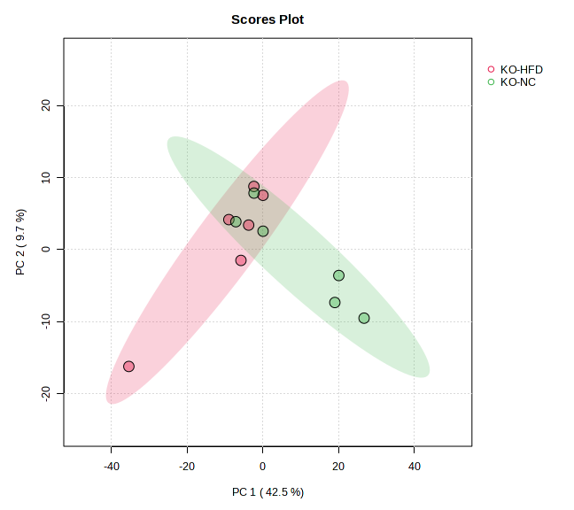

**Figure 5. PCA Scores Plot - Metabolite Profile Variations in Mice under KO-NC and KO-HFD groups**

**Loadings of PCA**

This table lists the PCA loadings for the top 20 metabolites contributing to the variation in metabolite profiles of mice under KO-NC and KO-HFD groups. Higher loadings indicate greater influence of a metabolite on the principal components, highlighting the most significant contributors to the observed metabolic differences between the two groups.

The original, full loading table can be found in the appendix, ../data/Download_KO-NC_KO-HFD/pca_loadings.csv

| Metabolites | class | PC1 | PC2 | PC3 | PC4 | PC5 |
| --- | --- | --- | --- | --- | --- | --- |
| PC aa C36:1 | Glycerophospholipids | -0.061 | 0.002 | 0.010 | -0.001 | -0.009 |
| PC ae C38:5 | Glycerophospholipids | -0.061 | 0.011 | 0.005 | -0.002 | -0.011 |
| PC aa C38:3 | Glycerophospholipids | -0.061 | 0.011 | 0.005 | -0.001 | -0.010 |
| PC ae C40:6 | Glycerophospholipids | -0.061 | 0.002 | 0.014 | -0.004 | -0.013 |
| PC aa C38:4 | Glycerophospholipids | -0.061 | 0.012 | 0.011 | 0.003 | -0.012 |
| PC aa C38:0 | Glycerophospholipids | -0.061 | -0.003 | 0.013 | 0.001 | -0.015 |
| PC ae C38:6 | Glycerophospholipids | -0.061 | 0.010 | 0.009 | -0.002 | -0.016 |
| PC ae C40:4 | Glycerophospholipids | -0.061 | -0.003 | 0.013 | 0.001 | -0.012 |
| PC ae C40:5 | Glycerophospholipids | -0.061 | 0.001 | 0.018 | 0.004 | -0.009 |
| PC aa C32:0 | Glycerophospholipids | -0.060 | 0.017 | 0.003 | 0.001 | -0.007 |
| PC ae C30:0 | Glycerophospholipids | -0.060 | -0.013 | 0.002 | -0.005 | 0.000 |
| Hex2Cer(d18:1/18:0) | Glycosylceramides | -0.060 | 0.008 | 0.010 | 0.009 | 0.003 |
| PC aa C36:2 | Glycerophospholipids | -0.060 | 0.012 | 0.008 | -0.004 | -0.013 |
| PC ae C34:3 | Glycerophospholipids | -0.060 | 0.011 | 0.008 | 0.001 | -0.003 |
| PC aa C36:0 | Glycerophospholipids | -0.060 | 0.014 | 0.011 | -0.002 | -0.019 |
| PC aa C40:4 | Glycerophospholipids | -0.060 | -0.005 | 0.014 | 0.001 | -0.013 |
| PC ae C40:3 | Glycerophospholipids | -0.060 | -0.007 | 0.009 | 0.003 | -0.011 |
| SM C24:0 | Sphingolipids | -0.060 | -0.006 | 0.012 | 0.007 | -0.012 |
| PC ae C42:2 | Glycerophospholipids | -0.060 | 0.002 | 0.018 | 0.000 | -0.012 |
| PC ae C38:1 | Glycerophospholipids | -0.060 | 0.008 | 0.012 | 0.004 | -0.019 |

**Table 1. PCA Loadings for Metabolite Profile Variations in Mice under KO-NC and KO-HFD groups**